# Heart Disease

Joshua Welch

April 17, 2018

## Heart

Here we are pulling in the data and changing the column names as we as setting columns to factors.

```r
heart = read.table("https://raw.githubusercontent.com/grbruns/cst383/master/heart.dat", quote = "/")
names(heart) <- c("AGE", "SEX", "CHESTPAIN", "RESTBP", "CHOL",
                  "SUGAR", "ECG", "MAXHR", "ANGINA", "DEP", "EXERCISE", "FLUOR",
                  "THAL", "OUTPUT")
names(heart) = tolower(names(heart))

# convert output to 0-1 range
heart$output = heart$output - 1

# categorical variables to factors
heart$sex = factor(heart$sex)
heart$sugar = factor(heart$sugar)
heart$angina = factor(heart$angina)
heart$chestpain = factor(heart$chestpain)
heart$ecg = factor(heart$ecg)
heart$thal = factor(heart$thal)
heart$exercise = factor(heart$exercise)
```

## Exploration

Looking at the data there is 270 rows of data with 14 columns. The data appears to have no missing or incomplete rows.

```r
summary(heart)
```

```
##       age        sex     chestpain     restbp           chol       sugar
##  Min.   :29.00   0: 87   1: 20     Min.   : 94.0   Min.   :126.0   0:230
##  1st Qu.:48.00   1:183   2: 42     1st Qu.:120.0   1st Qu.:213.0   1: 40
##  Median :55.00           3: 79     Median :130.0   Median :245.0
##  Mean   :54.43           4:129     Mean   :131.3   Mean   :249.7
##  3rd Qu.:61.00                     3rd Qu.:140.0   3rd Qu.:280.0
##  Max.   :77.00                     Max.   :200.0   Max.   :564.0
##  ecg         maxhr       angina       dep       exercise     fluor
##  0:131   Min.   : 71.0   0:181   Min.   :0.00   1:130    Min.   :0.0000
##  1:  2   1st Qu.:133.0   1: 89   1st Qu.:0.00   2:122    1st Qu.:0.0000
##  2:137   Median :153.5           Median :0.80   3: 18    Median :0.0000
##          Mean   :149.7           Mean   :1.05            Mean   :0.6704
##          3rd Qu.:166.0           3rd Qu.:1.60            3rd Qu.:1.0000
##          Max.   :202.0           Max.   :6.20            Max.   :3.0000
##  thal        output
##  3:152   Min.   :0.0000
##  6: 14   1st Qu.:0.0000
##  7:104   Median :0.0000
##          Mean   :0.4444
##          3rd Qu.:1.0000
##          Max.   :1.0000
```

```r
str(heart)
```

```
## 'data.frame':    270 obs. of  14 variables:
##  $ age      : num  70 67 57 64 74 65 56 59 60 63 ...
##  $ sex      : Factor w/ 2 levels "0","1": 2 1 2 2 1 2 2 2 2 1 ...
##  $ chestpain: Factor w/ 4 levels "1","2","3","4": 4 3 2 4 2 4 3 4 4 4 ...
##  $ restbp   : num  130 115 124 128 120 120 130 110 140 150 ...
##  $ chol     : num  322 564 261 263 269 177 256 239 293 407 ...
##  $ sugar    : Factor w/ 2 levels "0","1": 1 1 1 1 1 1 2 1 1 1 ...
##  $ ecg      : Factor w/ 3 levels "0","1","2": 3 3 1 1 3 1 3 3 3 3 ...
##  $ maxhr    : num  109 160 141 105 121 140 142 142 170 154 ...
##  $ angina   : Factor w/ 2 levels "0","1": 1 1 1 2 2 1 2 2 1 1 ...
##  $ dep      : num  2.4 1.6 0.3 0.2 0.2 0.4 0.6 1.2 1.2 4 ...
##  $ exercise : Factor w/ 3 levels "1","2","3": 2 2 1 2 1 1 2 2 2 2 ...
##  $ fluor    : num  3 0 0 1 1 0 1 1 2 3 ...
##  $ thal     : Factor w/ 3 levels "3","6","7": 1 3 3 3 1 3 2 3 3 3 ...
##  $ output   : num  1 0 1 0 0 0 1 1 1 1 ...
```

```r
sum(is.na(heart))
```

```
## [1] 0
```

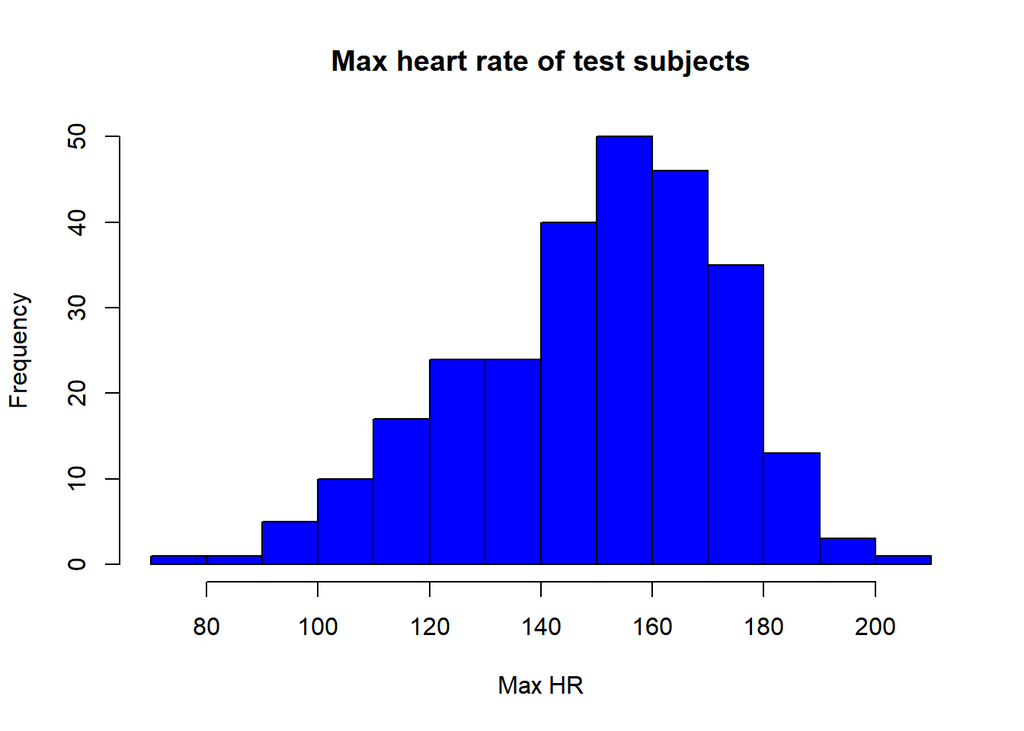

```r
hist(heart$maxhr, main="Max heart rate of test subjects", xlab="Max HR", col="blue")
```

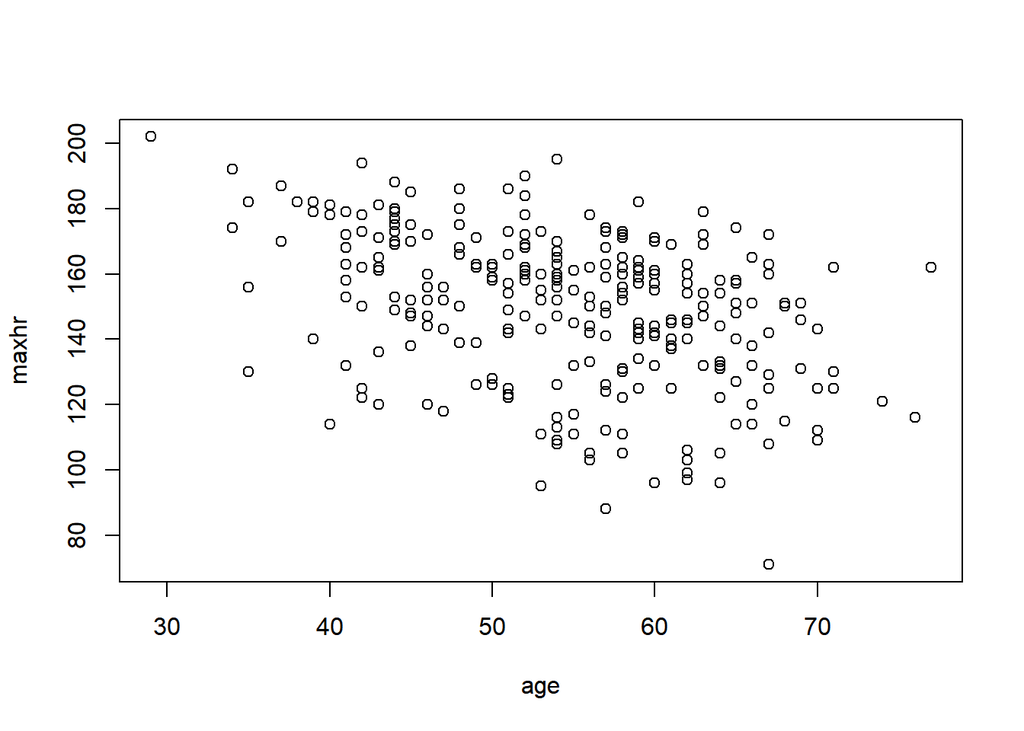

```r
plot(heart[,c("age","maxhr")])
```

## Building the Model 1

Model 1 is created simply using all of the columns, not the best idea but gives a good idea of the data to see which columns are more useful than others. Since the data set is rather small this is easy to run, where a larger data set could be problematic.

```r
nrows=nrow(heart)
tr_rows=sample(1:nrows, 0.7*nrows)
tr_dat=heart[tr_rows,]
te_dat=heart[-tr_rows,]
fit1 = glm(output ~ ., data=tr_dat, family=binomial)
summary(fit1)
```

```
##
## Call:
## glm(formula = output ~ ., family = binomial, data = tr_dat)
##
## Deviance Residuals:
##     Min       1Q   Median       3Q      Max
## -2.7907  -0.4636  -0.1330   0.3486   2.4808
##
## Coefficients:
##              Estimate Std. Error z value Pr(>|z|)
## (Intercept) -8.963434   3.860904  -2.322  0.02026 *
## age         -0.007691   0.032696  -0.235  0.81404
## sex1         1.736067   0.703630   2.467  0.01361 *
## chestpain2   1.776672   1.102089   1.612  0.10694
## chestpain3   0.821999   0.942669   0.872  0.38321
## chestpain4   2.519789   0.927760   2.716  0.00661 **
## restbp       0.037050   0.014954   2.478  0.01323 *
## chol         0.005590   0.004964   1.126  0.26009
## sugar1      -0.460857   0.699827  -0.659  0.51020
## ecg1         0.490843   2.820782   0.174  0.86186
## ecg2         0.891067   0.522032   1.707  0.08784 .
## maxhr       -0.020204   0.013314  -1.517  0.12916
## angina1      0.467372   0.557086   0.839  0.40149
## dep          0.225841   0.297116   0.760  0.44719
## exercise2    1.524772   0.617311   2.470  0.01351 *
## exercise3    0.625988   1.135402   0.551  0.58140
## fluor        1.384066   0.342643   4.039 5.36e-05 ***
## thal6       -0.282830   0.932896  -0.303  0.76176
## thal7        1.560776   0.558314   2.796  0.00518 **
## ---
## Signif. codes:  0 '***' 0.001 '**' 0.01 '*' 0.05 '.' 0.1 ' ' 1
##
## (Dispersion parameter for binomial family taken to be 1)
##
##     Null deviance: 260.10  on 188  degrees of freedom
## Residual deviance: 118.97  on 170  degrees of freedom
## AIC: 156.97
##
## Number of Fisher Scoring iterations: 6
```

From the summary we can see which columns are more useful than others, all though this doesn’t take into account combination of columns.

```r
y = predict(fit1, newdata=te_dat, type="response")
predicts = as.numeric(y > 0.6)
actuals = te_dat$output
conf_mtx = table(predicts, actuals)
conf_mtx
```

```
##         actuals
## predicts  0  1
##        0 45  7
##        1  1 28
```

```r
succ_rate = mean(predicts == actuals)
round(succ_rate, 3)
```

```
## [1] 0.901
```

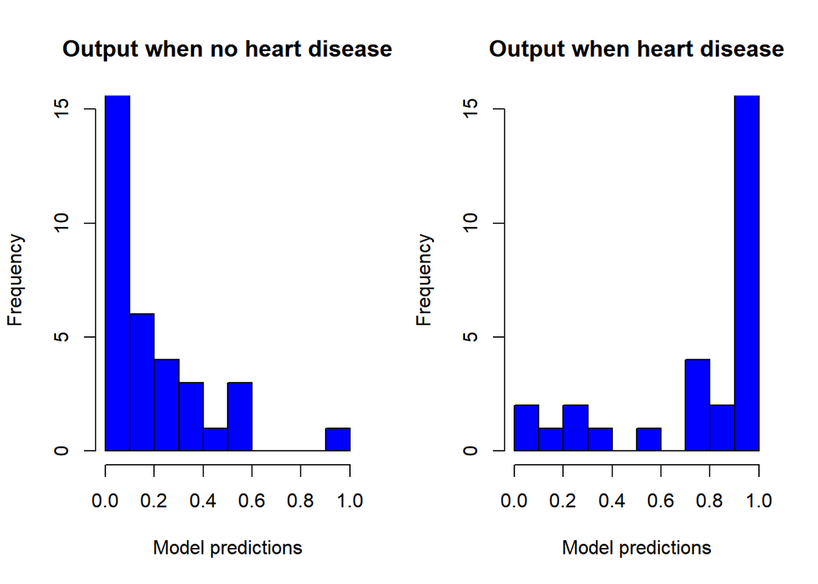

```r
par(mfrow=c(1,2))
hist(y[actuals == 0], main="Output when no heart disease",
breaks=10, xlim=c(0,1), ylim=c(0,15), col="blue", xlab="Model predictions")
hist(y[actuals == 1], main="Output when heart disease",
breaks=10, xlim=c(0,1), ylim=c(0,15), col="blue", xlab="Model predictions")
```

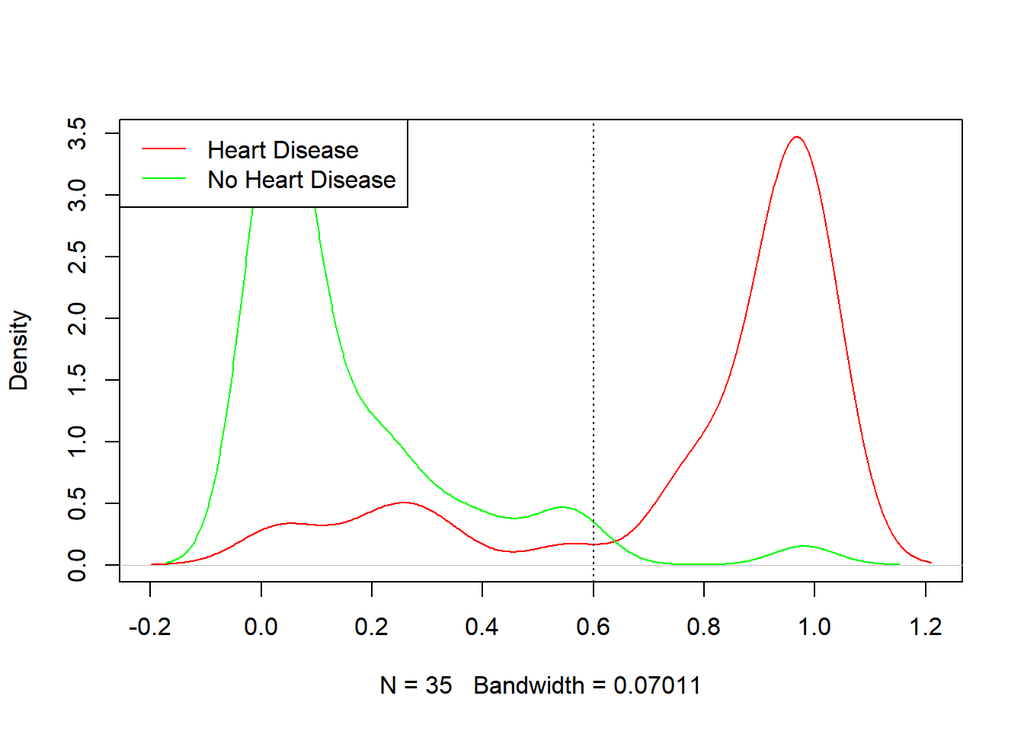

```r
plot(density(y[actuals == 1]), col="red", main="")
lines(density(y[actuals == 0]), col="green")
abline(v=0.6, lty=3)
legend("topleft", c("Heart Disease","No Heart Disease"), col= c("red","green"), lty=1)
```

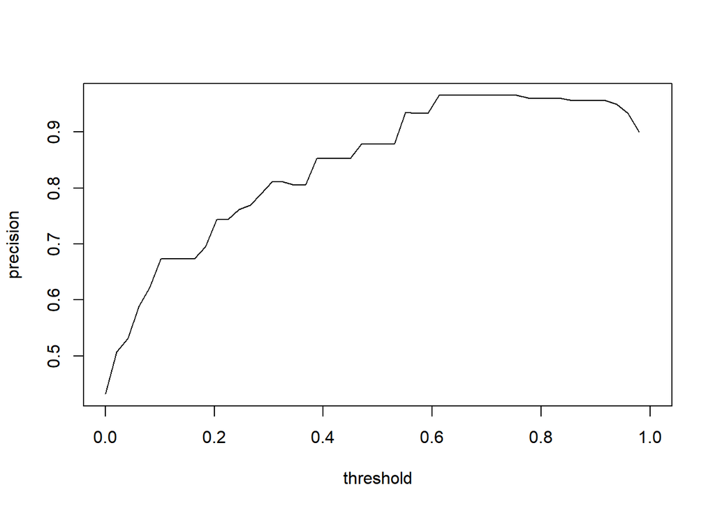

```r
prec_recall_summary = function(predicts, actuals){
thresh = seq(0, 1, length.out=50)
prec_rec = data.frame()
actuals = factor(as.numeric(actuals))
for (th in thresh){
predicts = factor(as.numeric(y >= th), levels=c("0","1"))
prec_rec = rbind(prec_rec, as.vector(table(predicts, actuals)))
}
names(prec_rec) = c("TN", "FP", "FN", "TP")
prec_rec$threshold = thresh
prec_rec$precision = prec_rec$TP/(prec_rec$TP + prec_rec$FP)
prec_rec$recall    = prec_rec$TP/(prec_rec$TP + prec_rec$FN)
prec_rec$false_pos = prec_rec$FP/(prec_rec$FP + prec_rec$TN)
return(prec_rec)
}
prec_rec1 = prec_recall_summary(predicts, actuals)

plot(precision~threshold,data=prec_rec1, type="l")
```

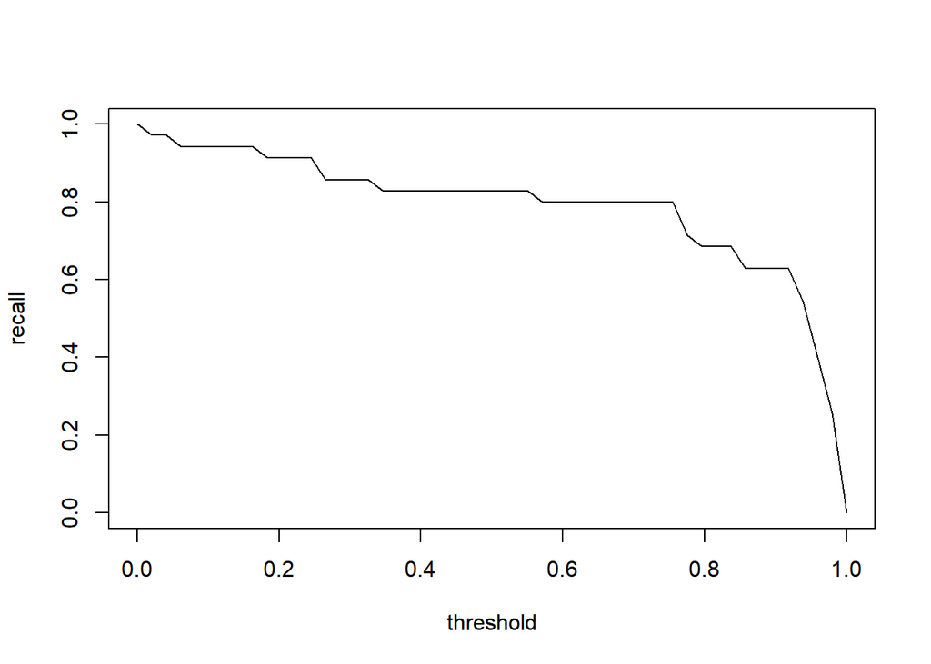

```r
plot(recall~threshold, data=prec_rec1, type="l")
```

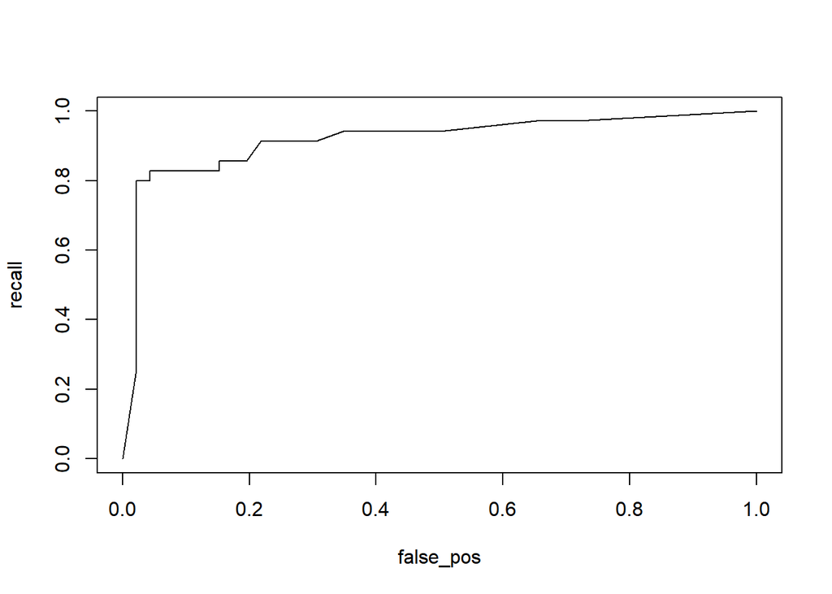

```r
plot(recall~false_pos, data=prec_rec1, type="l")
```

## Building Model 2

Model 2 is a little more careful by only choosing more beneficial columns and not using columns that have little to no effect.

```r
fit2 = glm(output ~ fluor + maxhr + thal, data=tr_dat, family=binomial)
summary(fit2)
```

```
##
## Call:
## glm(formula = output ~ fluor + maxhr + thal, family = binomial,
##     data = tr_dat)
##
## Deviance Residuals:
##     Min       1Q   Median       3Q      Max
## -2.7263  -0.6283  -0.3233   0.6312   2.1796
##
## Coefficients:
##              Estimate Std. Error z value Pr(>|z|)
## (Intercept)  3.513938   1.403111   2.504 0.012266 *
## fluor        1.089673   0.241771   4.507 6.57e-06 ***
## maxhr       -0.035974   0.009315  -3.862 0.000113 ***
## thal6        0.786514   0.765674   1.027 0.304318
## thal7        2.196809   0.418259   5.252 1.50e-07 ***
## ---
## Signif. codes:  0 '***' 0.001 '**' 0.01 '*' 0.05 '.' 0.1 ' ' 1
##
## (Dispersion parameter for binomial family taken to be 1)
##
##     Null deviance: 260.10  on 188  degrees of freedom
## Residual deviance: 163.73  on 184  degrees of freedom
## AIC: 173.73
##
## Number of Fisher Scoring iterations: 5
```

```r
y = predict(fit2, newdata=te_dat, type="response")
predicts = as.numeric(y > 0.6)
actuals = te_dat$output
conf_mtx = table(predicts, actuals)
conf_mtx
```

```
##         actuals
## predicts  0  1
##        0 43 10
##        1  3 25
```

```r
succ_rate = mean(predicts == actuals)
round(succ_rate, 3)
```

```
## [1] 0.84
```

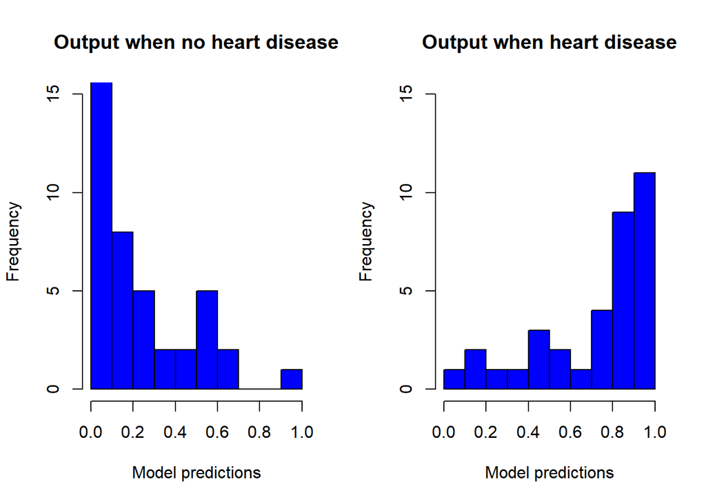

```r
par(mfrow=c(1,2))
hist(y[actuals == 0], main="Output when no heart disease",
breaks=10, xlim=c(0,1), ylim=c(0,15), col="blue", xlab="Model predictions")
hist(y[actuals == 1], main="Output when heart disease",
breaks=10, xlim=c(0,1), ylim=c(0,15), col="blue", xlab="Model predictions")
```

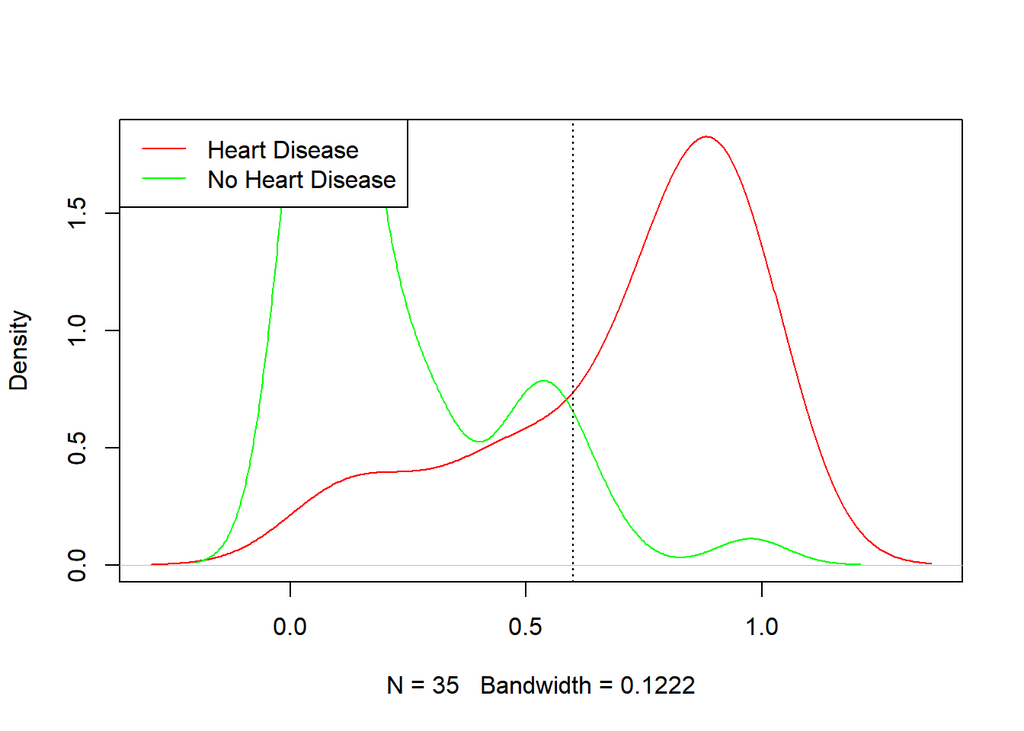

```r
plot(density(y[actuals == 1]), col="red", main="")
lines(density(y[actuals == 0]), col="green")
abline(v=0.6, lty=3)
legend("topleft", c("Heart Disease","No Heart Disease"), col= c("red","green"), lty=1)
```

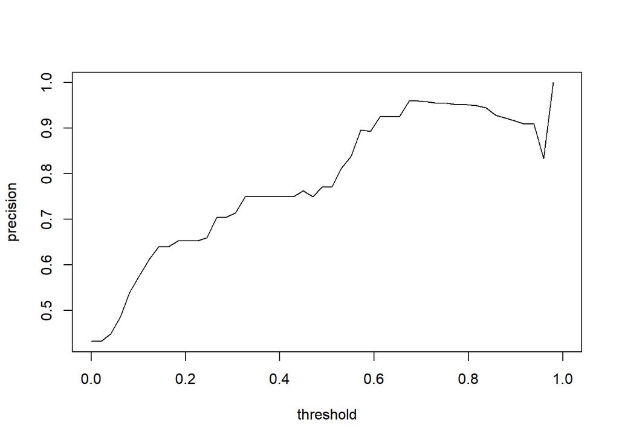

```r
prec_rec2 = prec_recall_summary(predicts, actuals)

plot(precision~threshold,data=prec_rec2, type="l")
```

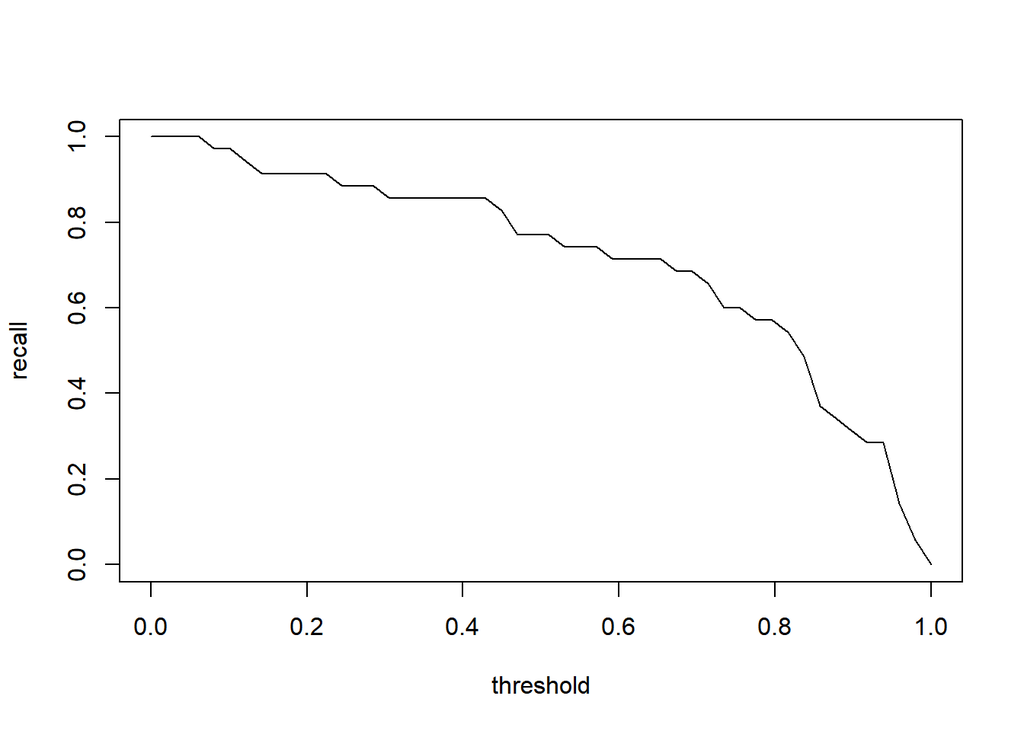

```r
plot(recall~threshold, data=prec_rec2, type="l")
```

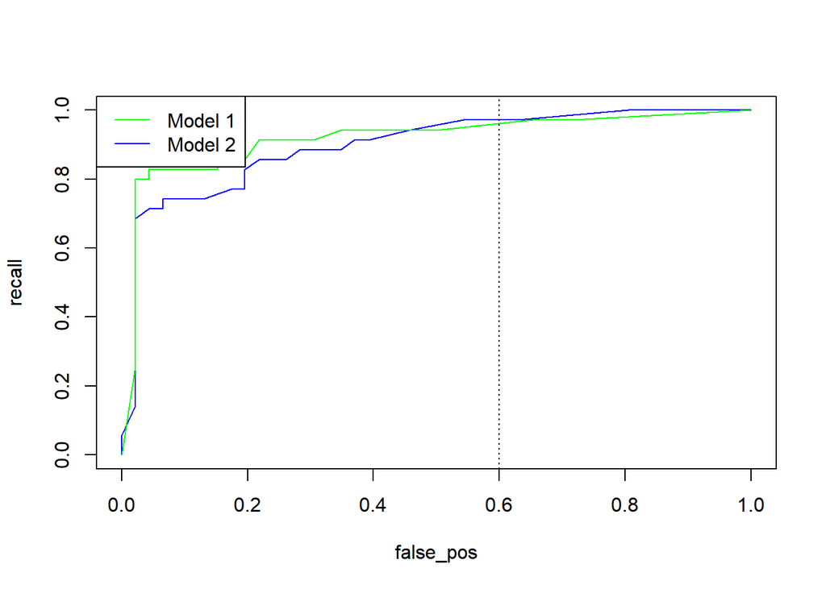

```r
plot(recall~false_pos, data=prec_rec2, type="l", col="blue")
lines(recall~false_pos, data=prec_rec1, type="l", col="green")
abline(v=0.6, lty=3)
legend("topleft", c("Model 1","Model 2"), col= c("green","blue"), lty=1)
```